# Chapter 6

5/26/2015

## Review: Comparing Variables

In previous chapters, we looked for relationships (associations) between variables by:

- Comparing categorical variables with contingency tables and stacked barplots
- Comparing numeric variables across groups with side-by-side boxplots
- Looked at how variables change over time with timeplots

In this chapter, we will:

- Look for relationships between two numeric variables

## The Data

Recall the Motor Trend Cars data from previous chapters:

```
##                    mpg cyl disp  hp    wt  qsec vs     am
## Mazda RX4         21.0   6  160 110 2.620 16.46  V   auto
## Mazda RX4 Wag     21.0   6  160 110 2.875 17.02  V   auto
## Datsun 710        22.8   4  108  93 2.320 18.61  S   auto
## Hornet 4 Drive    21.4   6  258 110 3.215 19.44  S manual
## Hornet Sportabout 18.7   8  360 175 3.440 17.02  V manual
## Valiant           18.1   6  225 105 3.460 20.22  S manual
```

We might want to know:

- Is there a relationship between engine displacement (size) and horsepower?
- Is weight related to fuel efficiency?

## Overview

How to we find relationships between numeric (quantitative) variables?

- Visually: using **scatterplots**
- Numerically: using the **correlation coefficient**
- Usually, we do both
- In this course, we will only focus on **linear** relationships

## Scatterplots

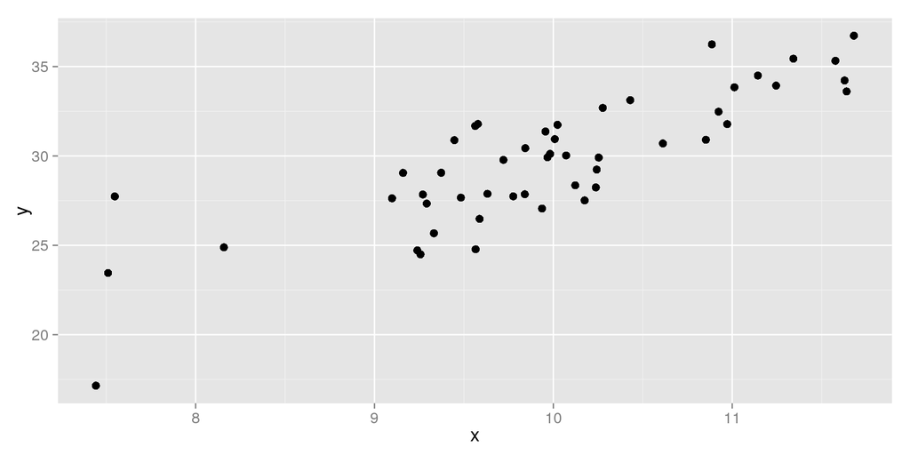

## Scatterplots

How to make scatterplots:

- Define one variable as the \(X\) variable, and one as \(Y\)
- Draw a point for each observation, using the values of the \(X\) and \(Y\) variables as coordinates
- Typically, the \(X\) variable is on the horizontal axis and the \(Y\) variable on the vertical axis

What we look for:

- Is there are trend or pattern?
- Are there any outliers or unusual points?

## Horsepower vs. Displacement

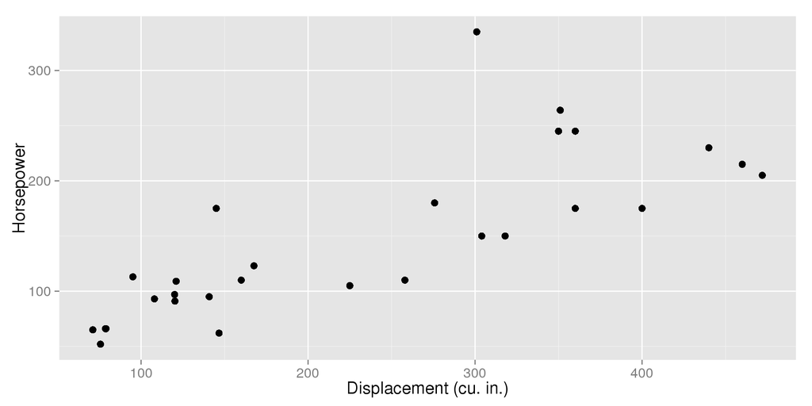

## Horsepower vs. Displacement

Is there a relationship?

- As engines get bigger, they tend to have more horsepower
- We call this a **positive** association

Are there any unusual points?

- There is a point well above the rest
- Notice that it's engine size is right in the middle (about 300 cu. in.), but its horsepower is larger than any other car

## Weight vs. Fuel Efficiency

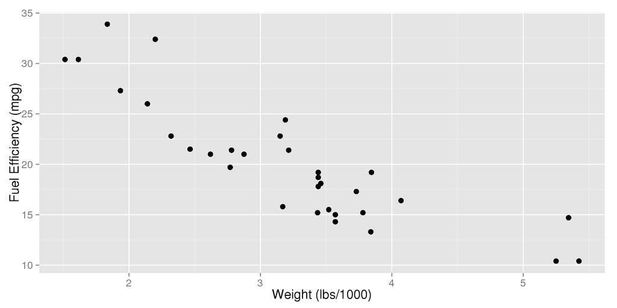

## Weight vs. Fuel Efficiency

Is there a relationship?

- As cars get heavier, they tend to have lower fuel efficiency
- We call this a **negative** association

Are there any outliers?

## Types of Relationships

There are many types of trends that can come up when we make scatterplots. In this class, we will focus on the most common:

- **Linear**: The trend can be described fairly well by a straight line
- **Non-linear**: Any other type of trend

Directions of Relationships

- **Positive**: As one variable goes up, so does the other one
- **Negative**: As one variable goes up, the other goes down

Why lines?

- In statistics, we often try to find the *simplest adequate method*. Lines are simple.

## Strong Positive Linear Trend

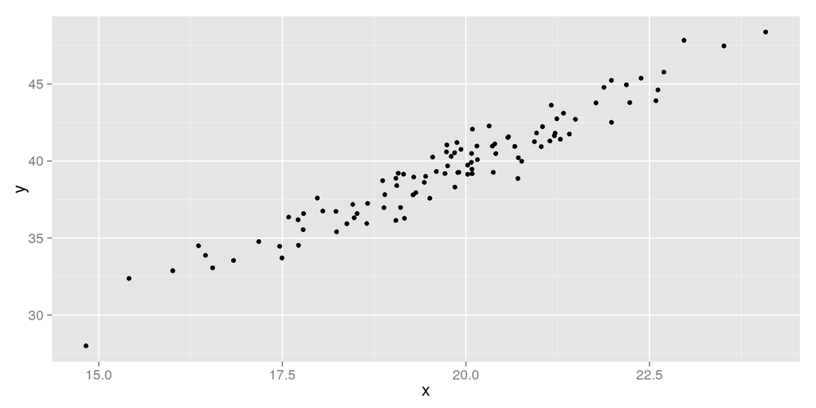

## Moderate Negative Linear Trend

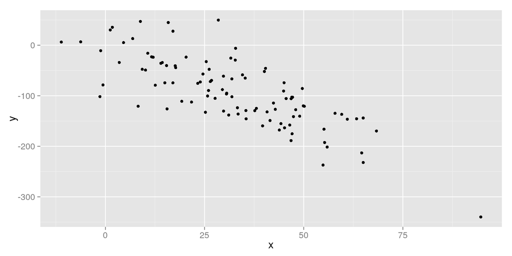

## Weak Positive Linear Trend

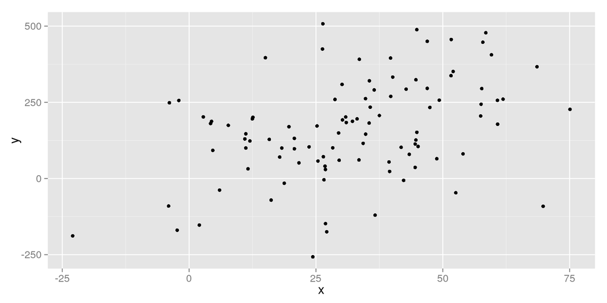

## No Trend

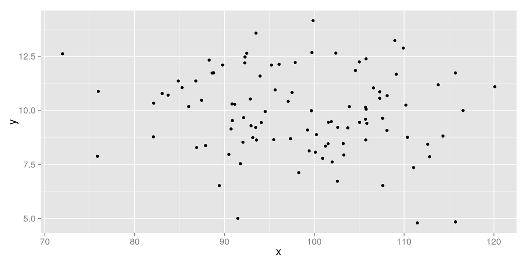

## Non-Linear Trend

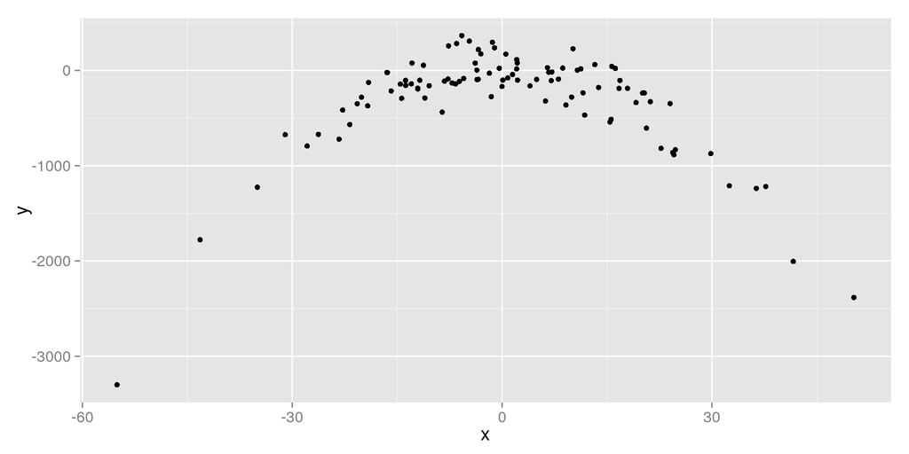

## Non-Linear Trend

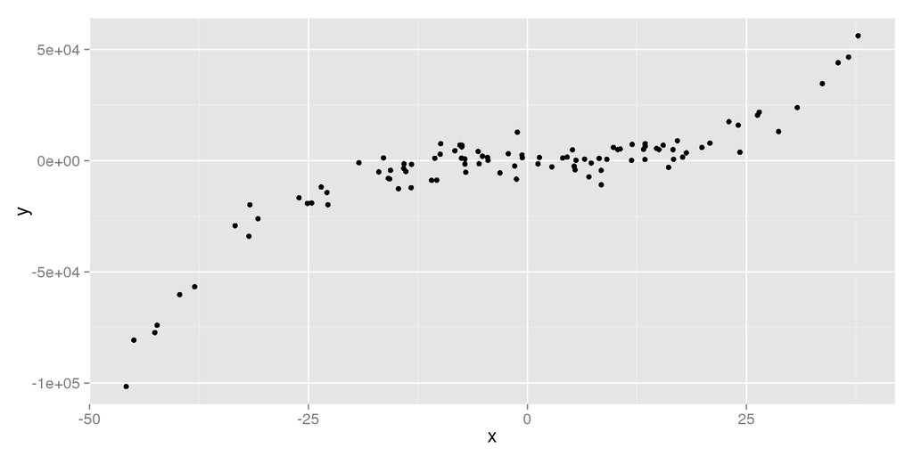

## Roles of Variables

How do we decide which is \(X\) and which is \(Y\)?

The \(X\) Variable is:

- The **explanatory** or **independent** variable.
- We want to know if changes in this variable *explains* changes in \(Y\)

The \(Y\) Variable is:

- The **response** or **dependent** variable
- We want to see if this variable *responds* when we change \(X\)

Which is which depends on what question we're asking.

## Variable Role Examples

Horsepower vs. Engine Displacement

- It makes sense that giving a car a bigger engine gives it more power.
- We can't just give a car more horsepower, horsepower *responds* to changes we make to the car.
- Horsepower should be \(Y\), and Engine Displacement should be \(X\).

Fuel Efficiency vs. Weight

- When we make a car heavier, it should mean that it takes more fuel to move it.
- Fuel efficiency *responds* to changes in the properties of the car.
- Fuel Efficiency should be \(Y\), and Weight should be \(X\).

## Measuring the Strength

How do we measure how strong the relationship is?

- We use the **correlation coefficient**
- \(r = \frac{\sum z_y \times z_x}{n-1}\)
- StatCrunch will find this for us

What is the correlation coefficient?

- \(r\) is the **strength of the linear relationship between two numeric variables**
- It tells us how well a straight line explains the relationship

## Interpreting Correlation

- \(-1 \le r \le 1\)
- The **value** of \(r\) tells us the strength
- The **sign** of \(r\) tells us the direction
- \(r = 1\): the points make a **perfect** straight line with a **positive** slope
- \(r = -1\): the points make a **perfect** straight line with a **negative** slope
- \(r = 0\): there is no linear relationship at all

Notes:

- You can sometimes get high correlations even if the relationship isn't linear
- You should **always** see a scatterplot along with a correlation coefficient to know whether or not it's meaningful

## Strong Positive Linear Trend

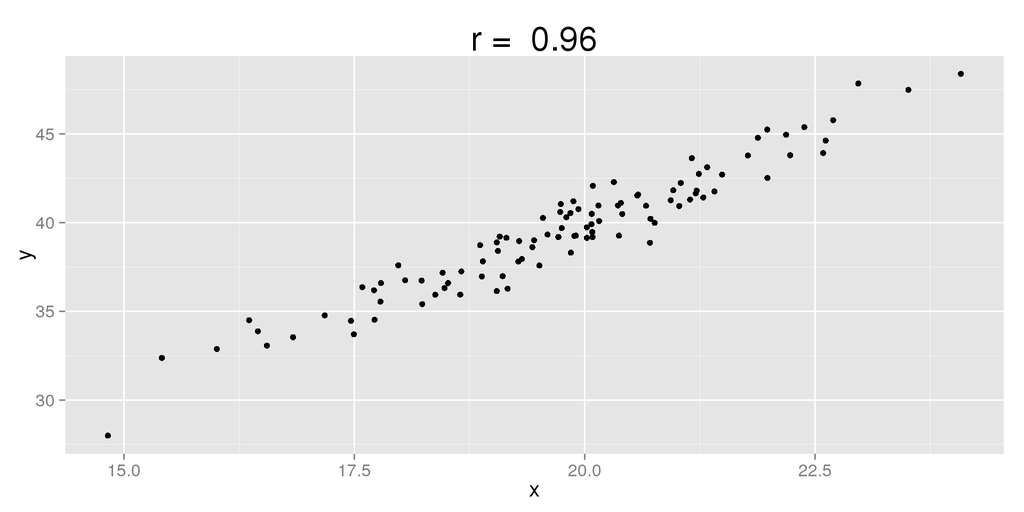

## Moderate Negative Linear Trend

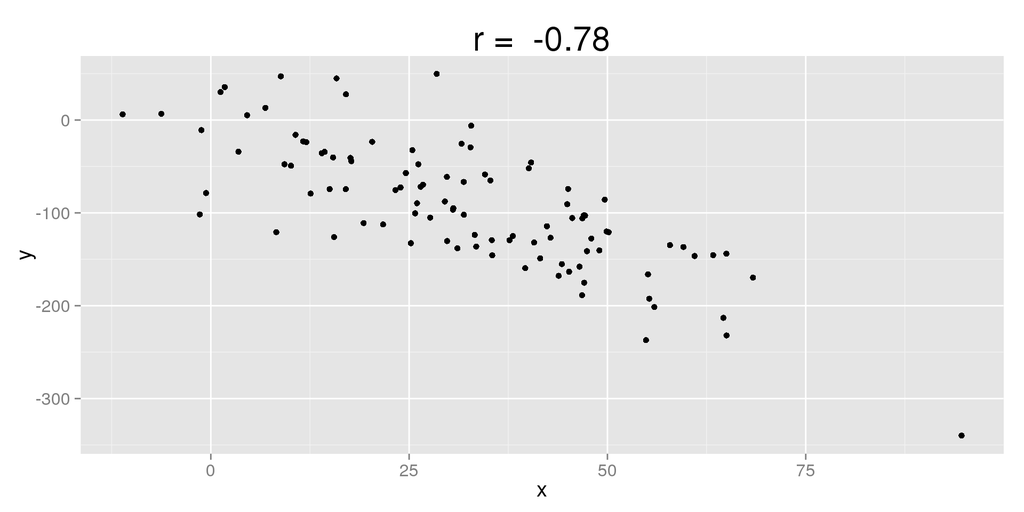

## Weak Positive Linear Trend

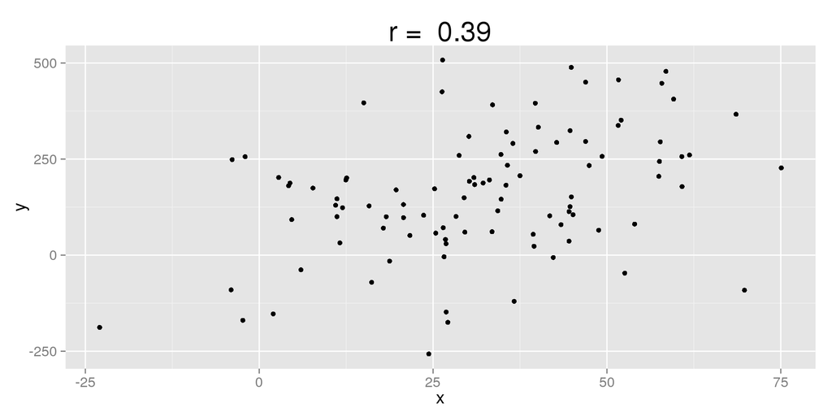

## No Trend

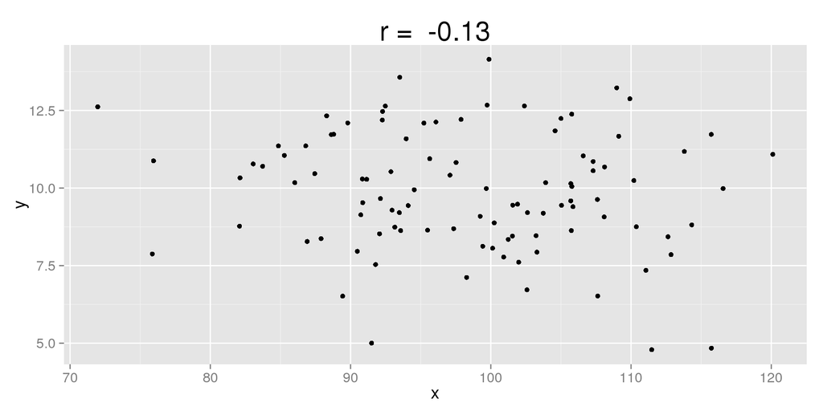

## Non-Linear Trend

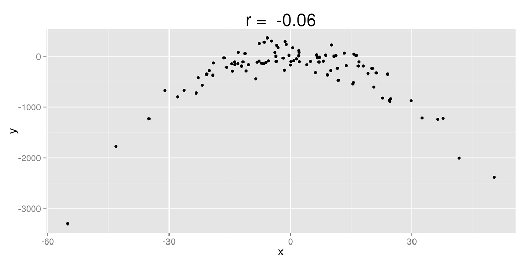

## Non-Linear Trend

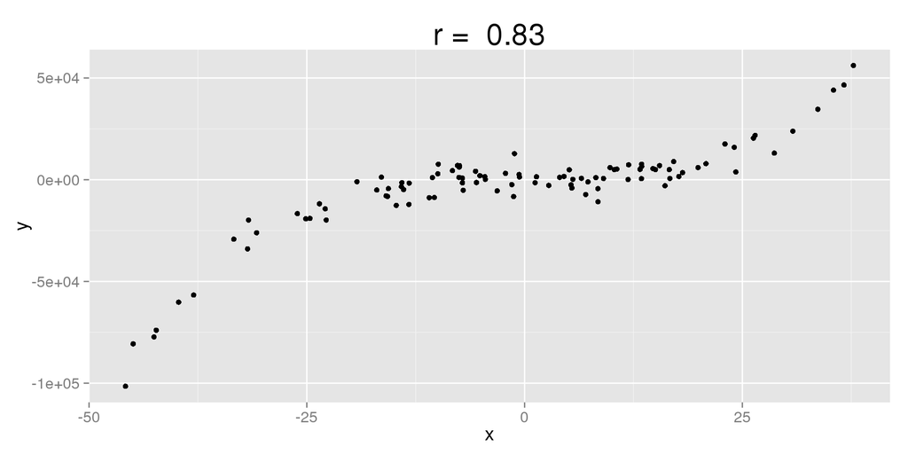

## Using the Correlation Coefficient

So how do we use \(r\)?

- First, make a scatterplot
- There needs to be a **linear** association, or \(r\) is meaningless
- Check the sign: is the relationship positive or negative?
- Check the value: how strong is the relationship?
- Are there outliers? The correlation is very sensitive to them.

Note:

- We often use the terms **weak**, **moderate**, and **strong** to describe the relationship, but these are up to interpretation.

## Horsepower vs. Engine Displacement

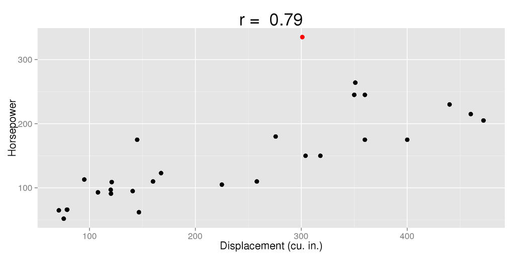

## Horsepower vs. Engine Displacement

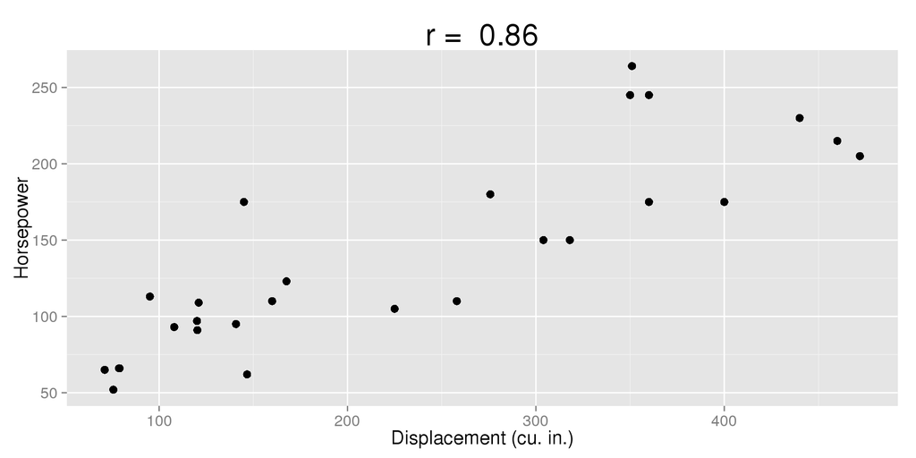

## More Properties of Correlation

- \(r\) is **unitless**
- \(r\) is not affected by changes of center or scale
- If we change units, the correlation will not change (e.g., \(lbs \to kg\))
- The correlation of \(X\) and \(Y\) is the same as the correlation between \(Z_x\) and \(Z_y\) (their z-scores)
- The correlation stays the same if we flip \(X\) and \(Y\)
- Correlation only applies to relationships between **numeric** variables. If there is an association involving categorical variables, it is **not** correlation.

## Weight (lbs) vs. Fuel Efficiency

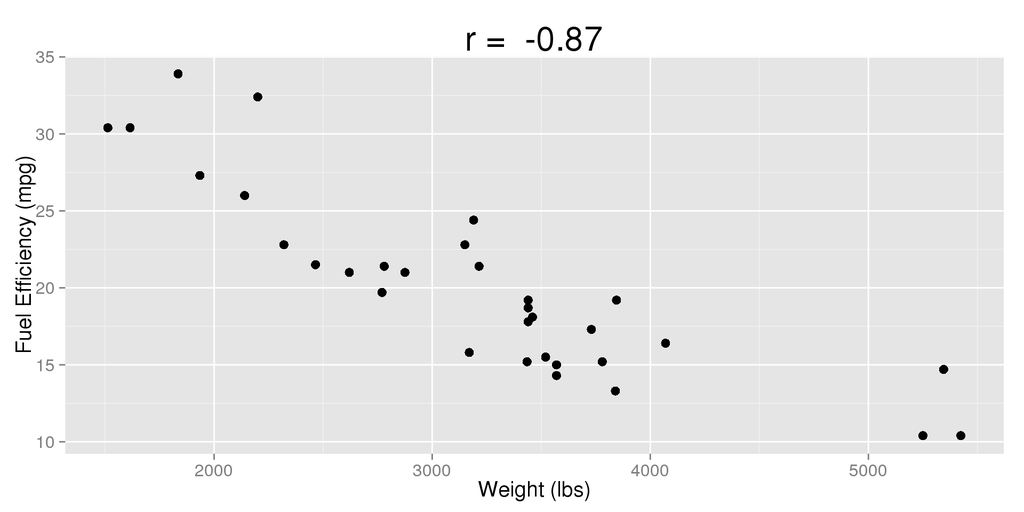

## Weight (kg) vs. Fuel Efficiency

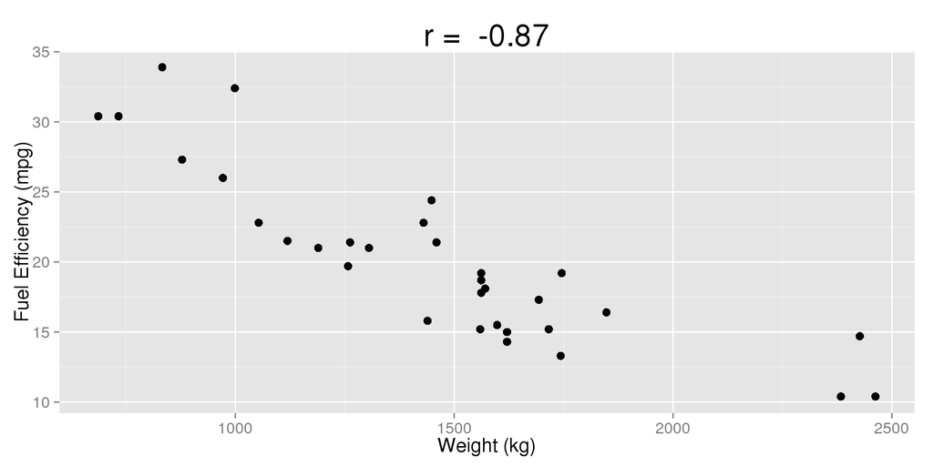

## Weight vs. Fuel Efficiency (Z-Scores)

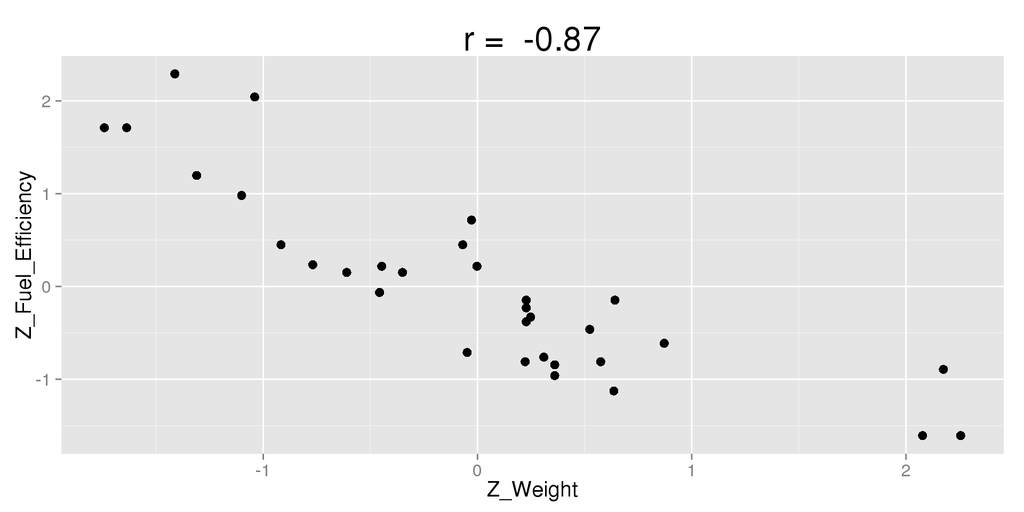

## Fuel Efficiency vs. Weight

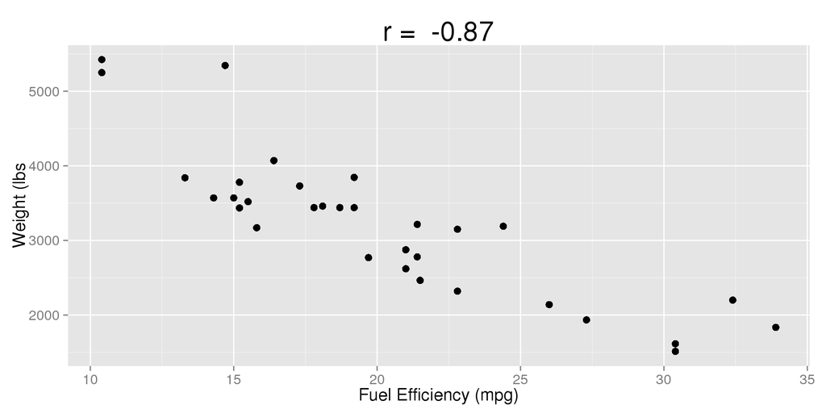

## In StatCrunch

Scatterplots:

1. `Graph` \(\to\) `Scatter Plot`
2. `X Column` \(\to\) Select your explanatory \((X)\) variable
3. `Y Column` \(\to\) Selected your response \((Y)\) variable
4. `Compute!`

Correlation:

1. `Stat` \(\to\) `Summary Stats` \(\to\) `Correlation`
2. `Select Column(s)` \(\to\) Hold `Shift`/`Ctrl`/`Command` to select multiple variables (note: if you select more than two variables, it will find all pair-wise correlations)
3. `Compute!`

## Correlation \(\ne\) Causation

Must people are familiar with the phrase "correlation does not equal causation," but what does that really mean?

- Even if we find a correlation between two variables, it does not mean that one causes the other.
- This is especially common when two things both increase or decrease over time.
- Both may be caused by other, unknown variables.
- We call these unknown variables **lurking variables** or **confounding variables**.

For example:

- What if we looked at the correlation between national ice cream sales and the number of forest fires, recorded for each month of the year?

## Ice Cream Sales and Forest Fires

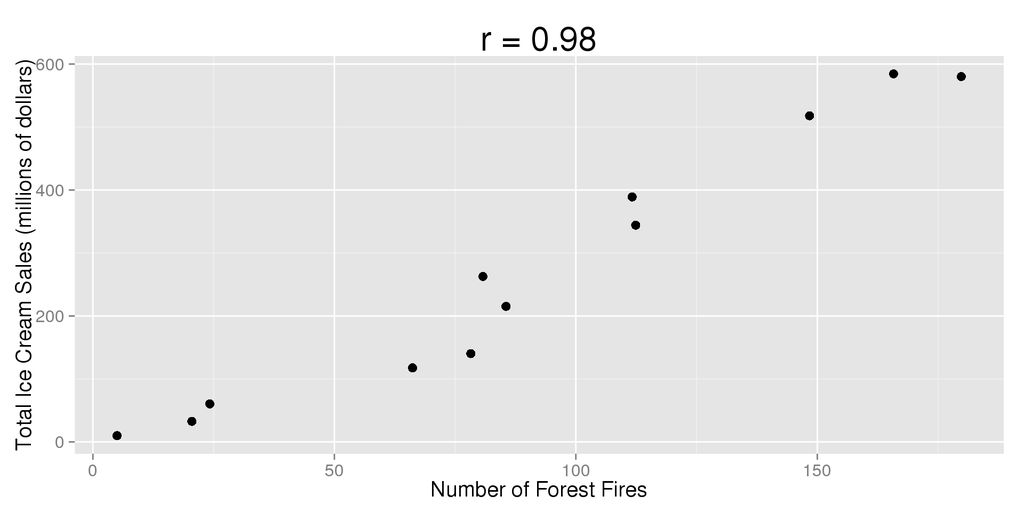

## Ice Cream Sales and Forest Fires

It certainly looks like there is a relationship.

- As the number of forest fires increase, the amount of ice cream being sold does as well
- If you open a pint of Ben & Jerries, does this light a patch of brush in California?
- The more likely explanation is the there is at least one lurking variable

What could it be?

- Both could be related to the month in which the information was collected
- Additionally, certain months tend to be hotter and drier.
- Both of these conditions lead to people wanting ice cream and forest fires being easier to start

## Forest Fires vs. Month

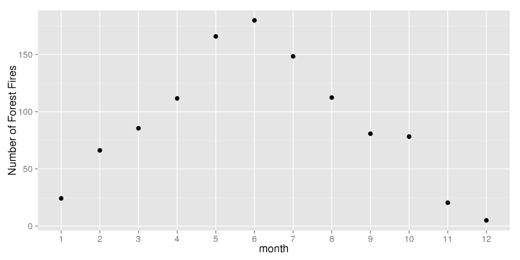

## Ice Cream Sales vs. Month

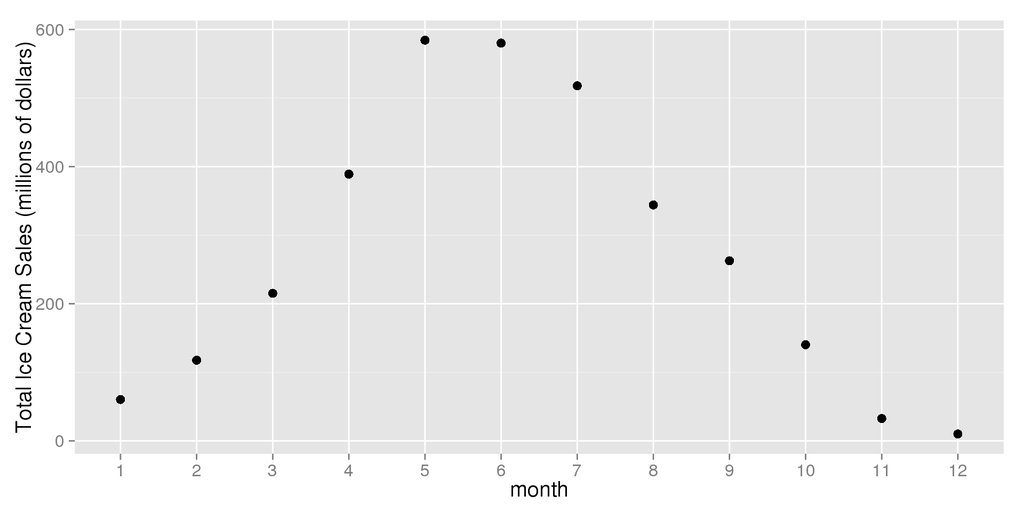

## Reporting Correlation

Employee Salaries and Productivity, \(r = .8\):

- **Bad**: Raising salaries increases productivity.
- **Good**: Employees with higher salaries tend to be more productive.

Red Wine and Cholesterol, \(r = −0.99\):

- **Bad**: This proves that drinking more red wine lowers cholesterol.
- **Good**: There is a strong negative association between red wine consumption and cholesterol level.

Parents' and Children's Education Levels (association, not correlation):

- **Bad**: A child that has two educated parents will graduate from college.
- **Good**: Children whose parents are educated are more likely to graduate from college

## Summary

- We can use scatterplots to find relationships and outliers between two numeric variables
- The \(X\) variable is the **explanatory** variable
- The \(Y\) variable is the **response** variable
- A relationship between variables is called **association**
- We can measure the strength of a **linear relationship** between two **numeric variables** using **correlation**
- Correlation doesn't neccessarily imply causation, there may be lurking variables